# Repeated measures Anova

Christian Burkhart

2018-07-07

# Einführung

In diesem Skript führen wir eine einfache Repeated Measures Anova durch. Die Daten sind Cholesterinwerte über mehrere Wochen von eine paar Patienten.

```r
library(tidyverse)
library(car)
library(emmeans)
library(conflicted)
library(sjstats)
library(afex)
afex::set_sum_contrasts()
```

Beginnen wir mit einem einfachen Beispiel. Unser Datensatz beschäftigt sich mit der Ernährung von Menschen.

```r
cholesterol <- read_csv("cholesterol.csv") %>%
  mutate(
    Margarine = factor(Margarine),
    ID        = factor(ID)
  )
glimpse(cholesterol)
```

```
## Observations: 18
## Variables: 5
## $ ID          <fct> 1, 2, 3, 4, 5, 6, 7, 8, 9, 10, 11, 12, 13, 14, 15,...
## $ Before      <dbl> 6.42, 6.76, 6.56, 4.80, 8.43, 7.49, 8.05, 5.05, 5....
## $ After4weeks <dbl> 5.83, 6.20, 5.83, 4.27, 7.71, 7.12, 7.25, 4.63, 5....
## $ After8weeks <dbl> 5.75, 6.13, 5.71, 4.15, 7.67, 7.05, 7.10, 4.67, 5....
## $ Margarine   <fct> B, A, B, A, B, A, B, A, B, A, B, B, A, A, A, B, A, B
```

Insgesamt gibt es 3 Messzeitpunkte. Initial und je 4 Wochen nach Beginn der Diät. Die Variable Margarine vernachlässigen wir einmal. Diesen Hauptfaktor schauen wir uns im nächsten Schritt an. Dann hätten wir eine One-Way Anova mit Repeated Measures.

Zunächst sollten wir uns die Daten einmal ansehen. Dafür sollten wir die Daten aber in das richtige Format für R bringen:

```r
# Data to long format
cholesterol_long <- cholesterol %>%
  gather(time, cholesterol, -ID, -Margarine,
         factor_key = TRUE)
```

Nun können wir die Daten auch in einem Boxplot darstellen.

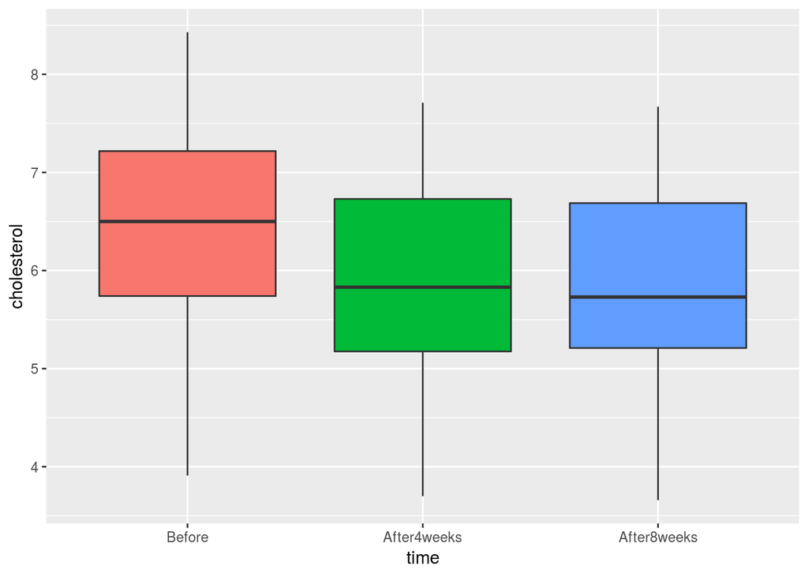

```r
ggplot(cholesterol_long, aes(x = time, y = cholesterol)) +
  geom_boxplot(aes(fill = time)) +
  guides(fill = FALSE)
```

Es scheint ein wenig so, als würde der Cholesterinspiegel nach 4 Wochen sinken, dann aber gleich bleiben. Wir möchten nun heraus finden, ob diese Veränderung auch signifikant ist. Dazu brauchen wir ein Repeated-Measures Design. Wir verwenden hierfür afex.

[afex](https://www.psychologie.uni-heidelberg.de/ae/meth/team/mertens/blog/anova_in_r_made_easy.nb.html)

```r
# model <- aov(cholesterol ~ time + Error(ID/time),
#              data = cholesterol_long)
(model2 <- aov_car(cholesterol ~ Error(ID|time),
                  data = cholesterol_long))
```

```
## Anova Table (Type 3 tests)
##
## Response: cholesterol
##   Effect          df  MSE          F ges p.value
## 1   time 1.24, 21.00 0.02 212.32 *** .06  <.0001
## ---
## Signif. codes:  0 '***' 0.001 '**' 0.01 '*' 0.05 '+' 0.1 ' ' 1
##
## Sphericity correction method: GG
```

```r
(model3 <- aov_ez(id = "ID", dv = "cholesterol",
                 data = cholesterol_long,
                 within = "time"))
```

```
## Anova Table (Type 3 tests)
##
## Response: cholesterol
##   Effect          df  MSE          F ges p.value
## 1   time 1.24, 21.00 0.02 212.32 *** .06  <.0001
## ---
## Signif. codes:  0 '***' 0.001 '**' 0.01 '*' 0.05 '+' 0.1 ' ' 1
##
## Sphericity correction method: GG
```

```r
model3 %>% summary
```

```
##
## Univariate Type III Repeated-Measures ANOVA Assuming Sphericity
##
##              Sum Sq num Df Error SS den Df F value    Pr(>F)
## (Intercept) 1950.12      1   65.866     17  503.33 4.542e-14 ***
## time           4.32      2    0.346     34  212.32 < 2.2e-16 ***
## ---
## Signif. codes:  0 '***' 0.001 '**' 0.01 '*' 0.05 '.' 0.1 ' ' 1
##
##
## Mauchly Tests for Sphericity
##
##      Test statistic    p-value
## time        0.38099 0.00044396
##
##
## Greenhouse-Geisser and Huynh-Feldt Corrections
##  for Departure from Sphericity
##
##       GG eps Pr(>F[GG])
## time 0.61766  3.888e-13 ***
## ---
## Signif. codes:  0 '***' 0.001 '**' 0.01 '*' 0.05 '.' 0.1 ' ' 1
##
##         HF eps   Pr(>F[HF])
## time 0.6418105 1.442841e-13
```

Es scheint einen signifikanten Effekt des Faktors time zu geben. Die Annahme, dass die Diät keinen Einfluss auf den Cholesterinspiegel hat, kann wiederrufen werden. Die Diät scheint den Cholesterinspiegel über die Wochen zu ändern. Aber wie?

Wir können uns die Konfidenzintervalle des Modells einmal genauer ansehen.

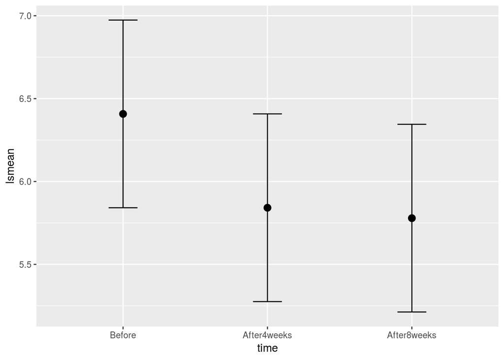

```r
conf_intervals <- model3 %>% lsmeans(specs = c("time")) %>% data.frame()
ggplot(conf_intervals, aes(x = time, y = lsmean)) +
  geom_errorbar(aes(ymin = lower.CL, ymax = upper.CL),
                width = .2) +
  geom_point(size = 3)
```

Als nächstes schauen wir uns an, welche Zeitpunkte signifikant unterschiedlich voneinander sind.

```r
model3 %>% lsmeans(specs = c("time")) %>%
  pairs
```

```
##  contrast                    estimate         SE df t.ratio p.value
##  Before - After4weeks      0.56611111 0.03361915 34  16.839  <.0001
##  Before - After8weeks      0.62888889 0.03361915 34  18.706  <.0001
##  After4weeks - After8weeks 0.06277778 0.03361915 34   1.867  0.1637
##
## P value adjustment: tukey method for comparing a family of 3 estimates
```

Der Post-Hoc Test zeigt, dass sich der erste vom zweiten und der erste vom dritten Messzeitpunkt signifikant unterscheiden.